# IODS course project

# Dimensionality reduction techniques

## Data wrangling

https://github.com/shinyk0514/IODS-project/blob/master/data/create_human.R

## Data analysis

### Task 1: Graphical overview and summary of the data

```r
human <- read.csv("C:\\Users\\Young Shin\\Documents\\IODS-project\\data\\human.csv")
str(human)
```

```
## 'data.frame':    155 obs. of  8 variables:
##  $ edu2F_M        : num  1.007 0.997 0.983 0.989 0.969 ...
##  $ labourF_M      : num  0.891 0.819 0.825 0.884 0.829 ...
##  $ life_expectancy: num  81.6 82.4 83 80.2 81.6 80.9 80.9 79.1 82 81.8 ...
##  $ schooling_yrs  : num  17.5 20.2 15.8 18.7 17.9 16.5 18.6 16.5 15.9 19.2 ...
##  $ GNI            : int  64992 42261 56431 44025 45435 43919 39568 52947 42155 32689 ...
##  $ maternal_mortal: int  4 6 6 5 6 7 9 28 11 8 ...
##  $ adol_birthrate : num  7.8 12.1 1.9 5.1 6.2 3.8 8.2 31 14.5 25.3 ...
##  $ parliamentF    : num  39.6 30.5 28.5 38 36.9 36.9 19.9 19.4 28.2 31.4 ...
```

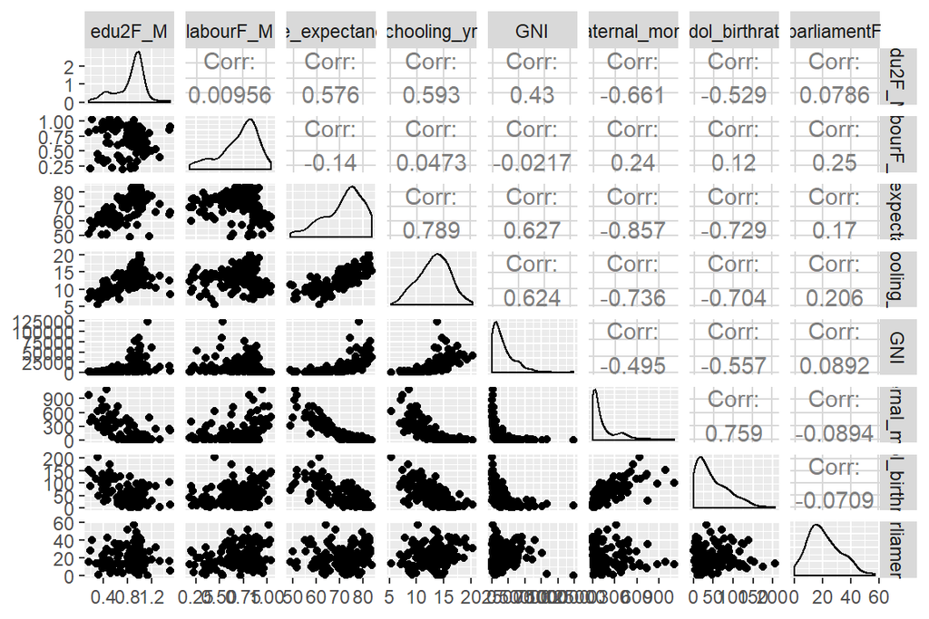

```r
library(GGally)
ggpairs(human)
```

```r
library(dplyr)
summary(human)
```

```
##     edu2F_M         labourF_M      life_expectancy schooling_yrs
##  Min.   :0.1717   Min.   :0.1857   Min.   :49.00   Min.   : 5.40
##  1st Qu.:0.7264   1st Qu.:0.5984   1st Qu.:66.30   1st Qu.:11.25
##  Median :0.9375   Median :0.7535   Median :74.20   Median :13.50
##  Mean   :0.8529   Mean   :0.7074   Mean   :71.65   Mean   :13.18
##  3rd Qu.:0.9968   3rd Qu.:0.8535   3rd Qu.:77.25   3rd Qu.:15.20
##  Max.   :1.4967   Max.   :1.0380   Max.   :83.50   Max.   :20.20
##       GNI         maternal_mortal  adol_birthrate    parliamentF
##  Min.   :   581   Min.   :   1.0   Min.   :  0.60   Min.   : 0.00
##  1st Qu.:  4198   1st Qu.:  11.5   1st Qu.: 12.65   1st Qu.:12.40
##  Median : 12040   Median :  49.0   Median : 33.60   Median :19.30
##  Mean   : 17628   Mean   : 149.1   Mean   : 47.16   Mean   :20.91
##  3rd Qu.: 24512   3rd Qu.: 190.0   3rd Qu.: 71.95   3rd Qu.:27.95
##  Max.   :123124   Max.   :1100.0   Max.   :204.80   Max.   :57.50
```

*The dataset has 155 observations of 8 variables, which are the raio of female to male populations with secondary education (edu2F_M), the ratio of female labour labour participation to male (labourF_M), life expectancy at birth (life_expectancy), expected years of education (schooling_yrs), Gross National Income GNI per capita (GNI), maternal motality ratio (maternal_motality), adolescent birth rate (adol_birthrate) and the pecentage of female parliament members (parliamentF).*

### Task 2: PCA on the non-standardized human data

```r
pca_human <- prcomp(human)
summary(pca_human)
```

```
## Importance of components:
##                              PC1      PC2   PC3   PC4   PC5   PC6    PC7
## Standard deviation     1.854e+04 185.5219 25.19 11.45 3.766 1.566 0.1912
## Proportion of Variance 9.999e-01   0.0001  0.00  0.00 0.000 0.000 0.0000
## Cumulative Proportion  9.999e-01   1.0000  1.00  1.00 1.000 1.000 1.0000
##                           PC8
## Standard deviation     0.1591
## Proportion of Variance 0.0000
## Cumulative Proportion  1.0000
```

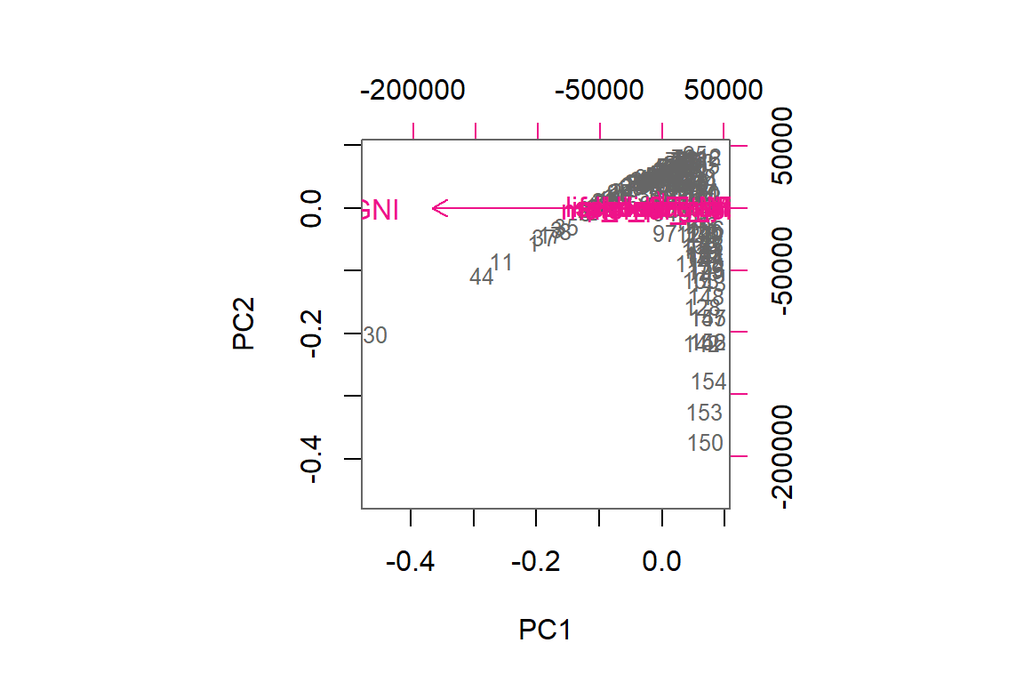

```r
biplot(pca_human, choices = 1:2, cex = c(0.8, 1), col = c("grey40", "deeppink2"))
```

*The result of PCA on the non-standardized variables shows that PC1 explains all of the variance between the variables. It seems that such a result is because GNI has larger variance than others*